# Segmentation: First Passage Time

[Brazil Move 2024 - UFMS - Campo Grande](https://eligurarie.github.io/BrazilMove2024)

Nicki Barbour and Elie Gurarie

May 22, 2024

# Goals

> To perform a first-passage time analysis on the elk data set to identify when it is in a “resident” (area restricted search) phase versus a “transiting” phase. We’ll use functionality in the `adehabitatLT` package.

```r
setwd("../..")
load("./data/elk_processed.rda")
head(elk_gps)
```

```
##              datetime       lon      lat   id
## 1 2001-12-13 07:01:00 -115.8043 52.12410 4049
## 2 2001-12-13 09:01:00 -115.8003 52.11762 4049
## 3 2001-12-14 09:01:00 -115.8281 52.09611 4049
## 4 2001-12-14 11:00:00 -115.8318 52.09829 4049
## 5 2001-12-14 17:02:00 -115.8042 52.09482 4049
## 6 2001-12-14 19:01:00 -115.8037 52.12493 4049
```

We will use one individual from the elk, “YL96”. This individual has some “patches” of residency-like behavior along its track.

```r
myelk <- subset(elk_gps, id == "YL96") |>
  dplyr::mutate(id = as.character(id))
```

The `scan track`:

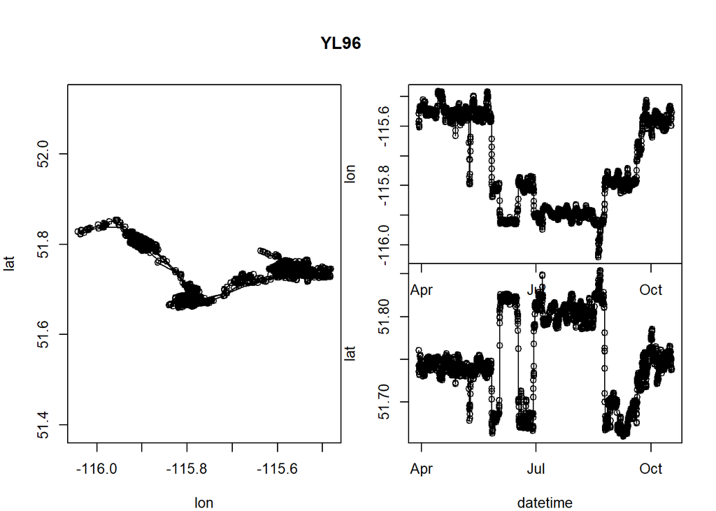

```r
layout(rbind(c(1,2), c(1,3)))
with(myelk, {
  plot(lon, lat, asp = 1, type="o")
  plot(datetime, lon, type="o", xlab = "")
  plot(datetime, lat, type="o")
  title(id[1], outer = TRUE)
})
```

# First Passage Time

First Passage Time (FPT) can be a useful parameter to describe scales of behavior along a movement track.

It is generally defined as the time observed for an animal to pass through a circle, with radius “r”, where “r” defines the scale of behavior.

The variance of the log of the FPT can be used to select this scale, “r”, with a high variance (peak) being seen for scales often used by more residential-like behavior (e.g., slower, more tortuous movements).

## The `ltraj` Data Format

Unfortunately the `adehabitatLT` does not work too well with simple feature projected data, but rather with the now outdates “Spatial Points” data type.

```r
library(adehabitatLT)
library(sf)
library(plyr)
```

In order to fit the `fpt` function, we first need to:

1 - make our data spatial (`sf`)

2 - convert our data to `SpatialPoints` format (`sp` which is automatically installed and loaded with the `adehabitatLT` package).

```r
myelk_sp <- myelk |>
  st_as_sf(coords=c("lon","lat"), crs= 4326) |>
  st_transform(32611) |>
  st_cast("POINT") |>
  as_Spatial()
```

We can now use the `as.ltraj` function to convert out data into ltraj format.

```r
myelk_traj <- as.ltraj(coordinates(myelk_sp),
                       date = myelk$datetime,
                       id = myelk$id)

summary(myelk_traj)
```

```
##     id burst nb.reloc NAs          date.begin            date.end
## 1 YL96  YL96     4129   0 2004-03-29 17:00:00 2004-10-17 09:00:00
```

Note, the `ltraj` data type is good for processing multiple individuals - and even multiple “bursts” (subsets of data) per individual. We won’t’use that functionality here.

We can use the `head` function to look at the ltraj data table for this individual. Note that in converting to `ltraj` many of the metrics that we also obtained are computed (step lengths, turning angles, etc.)

```r
head(myelk_traj[[1]])
```

```
##          x       y                date         dx          dy      dist   dt
## 1 599661.1 5733368 2004-03-29 17:00:00 -1960.2917  2004.18194 2803.4780 7320
## 2 597700.8 5735372 2004-03-29 19:02:00  -558.4716 -2829.92571 2884.5052 7140
## 3 597142.4 5732542 2004-03-29 21:01:00  -203.6384   -42.86034  208.1000 7200
## 4 596938.7 5732500 2004-03-29 23:01:00  -466.3606  -391.65474  609.0038 7140
## 5 596472.4 5732108 2004-03-30 01:00:00   244.5432   108.15146  267.3914 7260
## 6 596716.9 5732216 2004-03-30 03:01:00  1171.0849   346.35853 1221.2306 7140
##        R2n  abs.angle  rel.angle
## 1        0  2.3451241         NA
## 2  7859489 -1.7656377  2.1724236
## 3  7026021 -2.9341477 -1.1685101
## 4  8165944 -2.4430437  0.4911040
## 5 11756458  0.4163979  2.8594416
## 6  9995777  0.2875611 -0.1288368
```

We can also plot the trajectory of the individual, which shows the start and end locations in red and blue.

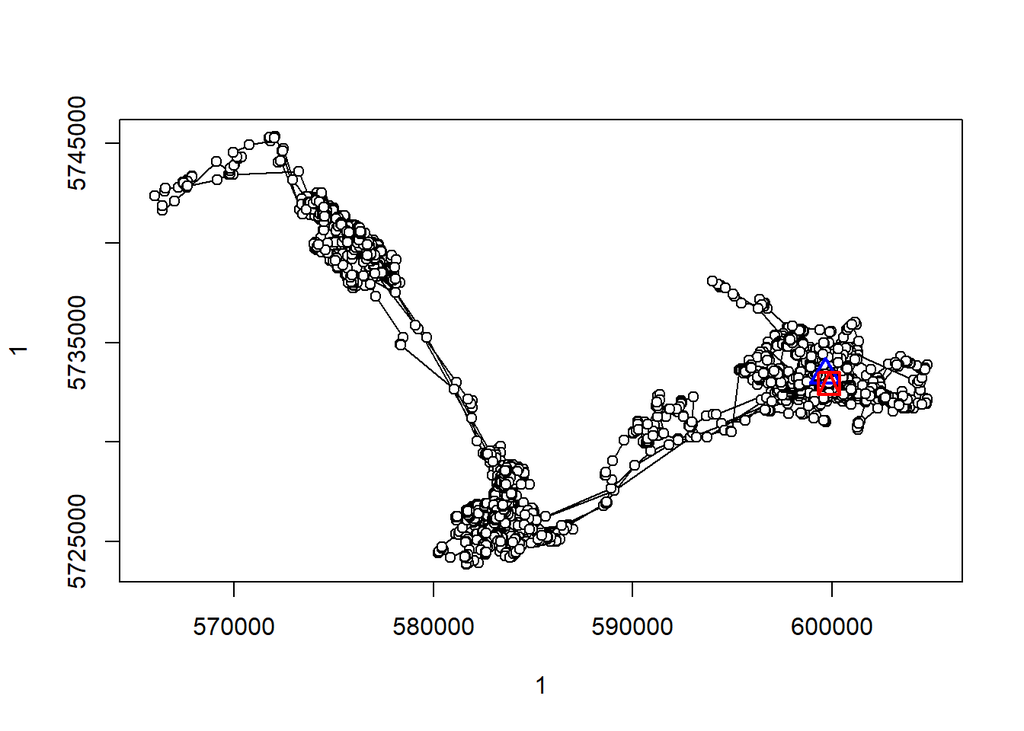

```r
plot(myelk_traj)
```

## Estimate First Passage time

```r
myelk_fpt_100 <- fpt(myelk_traj,
                 radii = 100,
                 units="hours")
myelk_fpt_1000 <- fpt(myelk_traj,
                 radii = 1000,
                 units="hours")
myelk_fpt_10000 <- fpt(myelk_traj,
                 radii = 10000,
                 units="hours")
```

Compare athese:

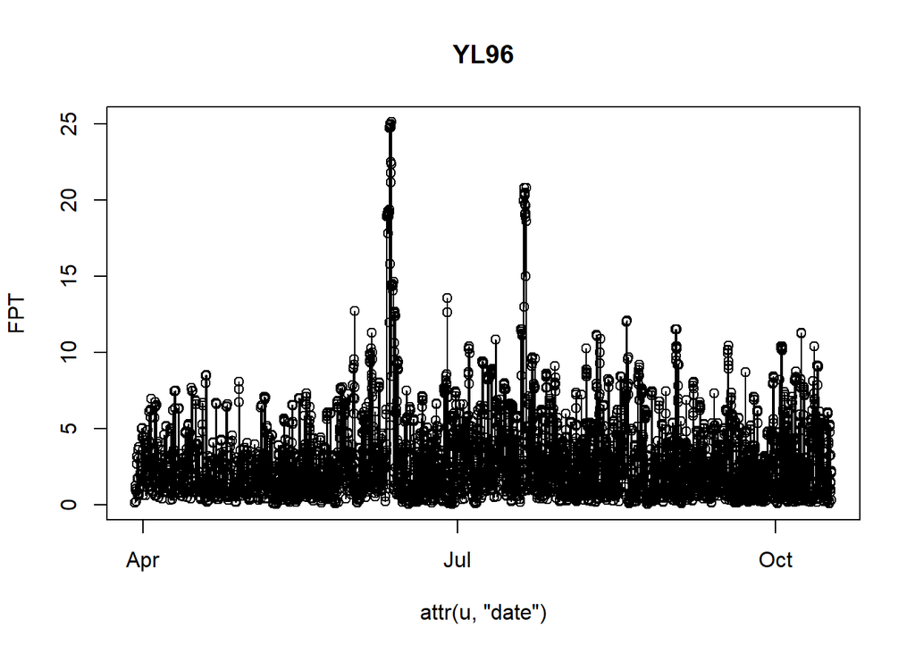

```r
plot(myelk_fpt_100, scale = 100)
```

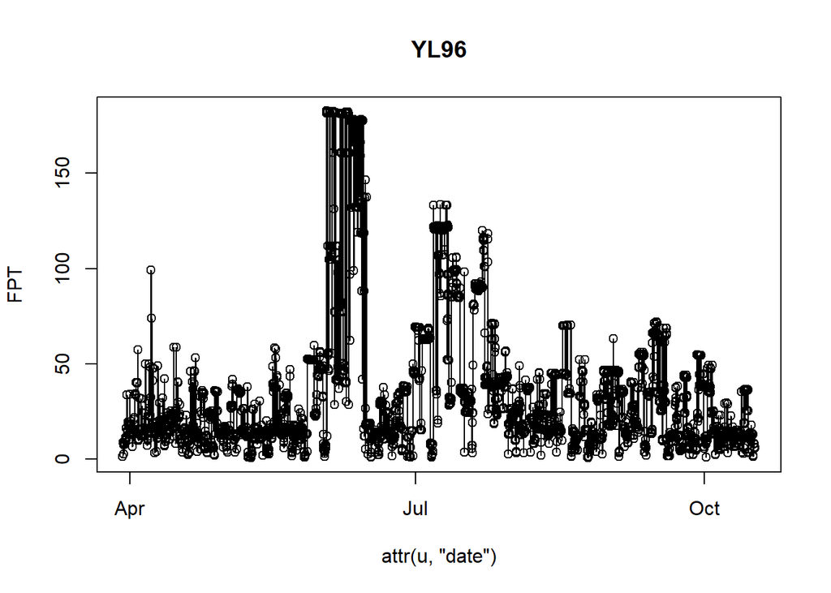

```r
plot(myelk_fpt_1000, scale = 1000)
```

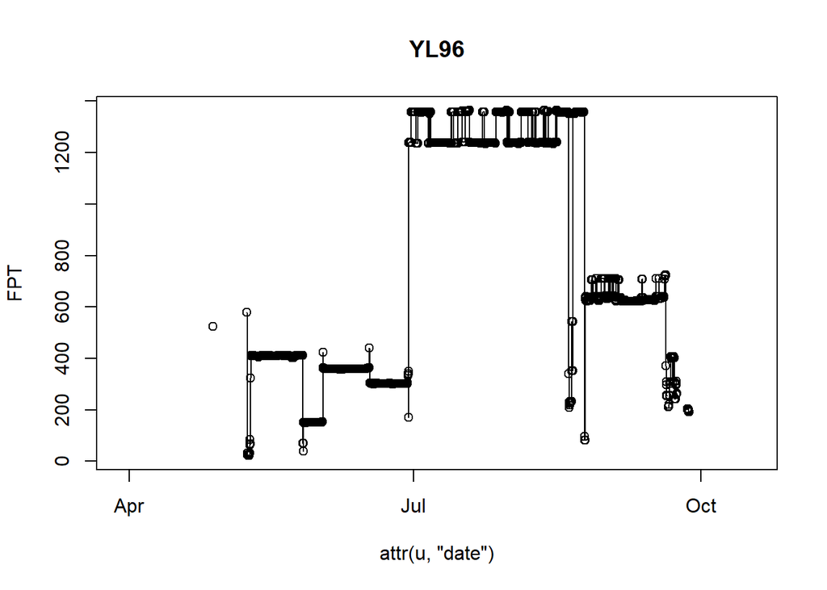

```r
plot(myelk_fpt_10000, scale = 10000)
```

> How do you interpret these!?

A common way to “select a scale” for the first passage tima analysis is to compare the *variance* of the first passage time across many scales. We find the FPT actoss all the scales at once, and use the `varlogfpt` function on our FPT object to see if we can find a peak in the variance at one of the spatial scales of interest.

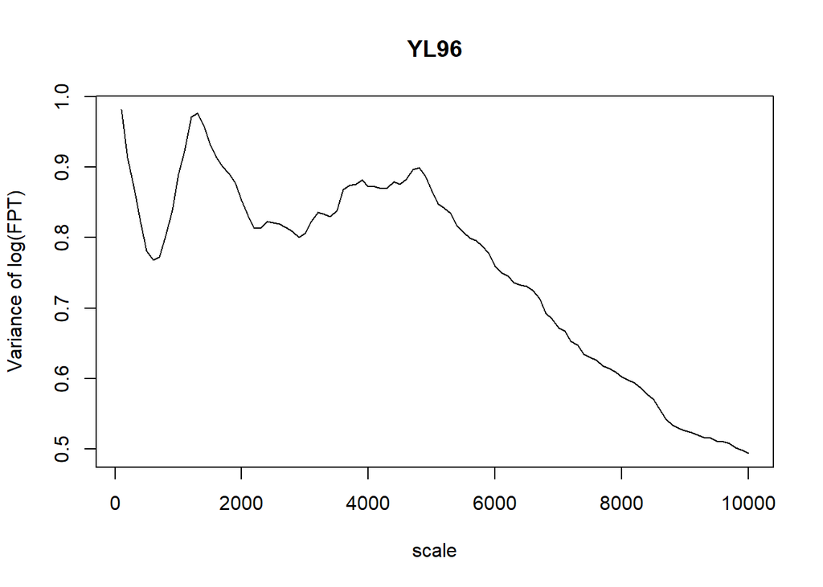

```r
myelk_fpt <- fpt(myelk_traj, radii = seq(100,10000,100))
varlogfpt(myelk_fpt, graph=TRUE)
```

Now that we have decided on our spatial scale of interest, we can refit our `fpt` function and plot the results.

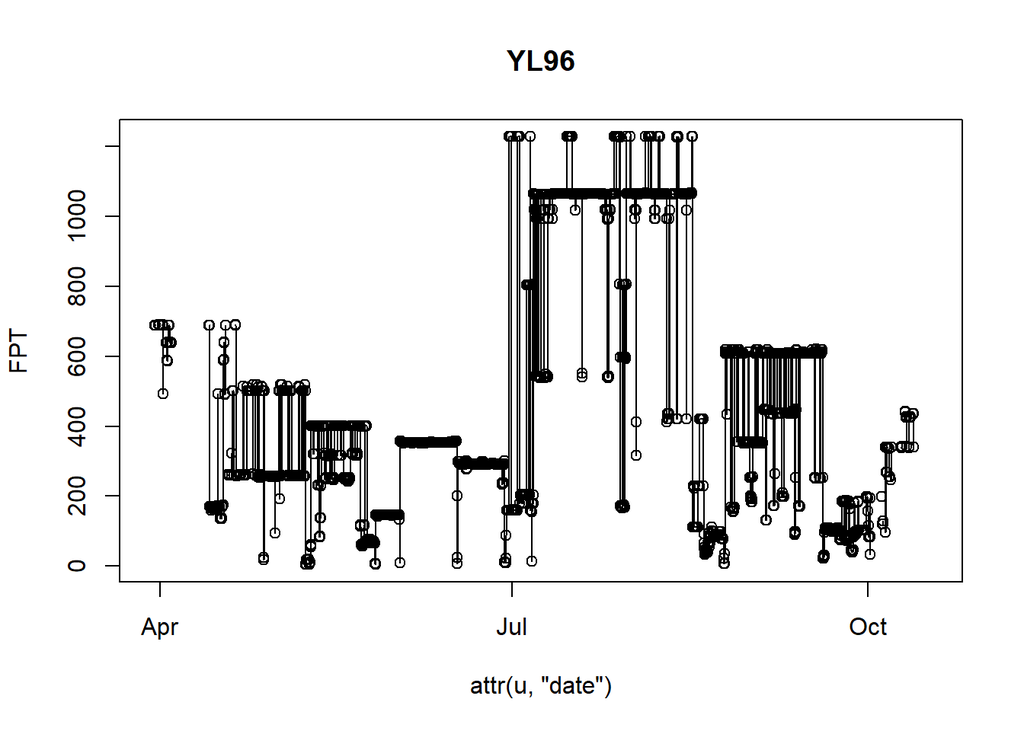

```r
myelk_fpt <- fpt(myelk_traj, radii = 5000, units="hours")
plot(myelk_fpt, scale = 5000, warn = FALSE)
```

We can bind our FPT values to our data as a column by extracting it from our FPT object.

```r
myelk$FPT <- myelk_fpt[[1]]$r1
```

Periods of higher FPT seem to mostly correspond to the distinct patches of possible “residential” behavior.

```r
library(ggplot2)
```

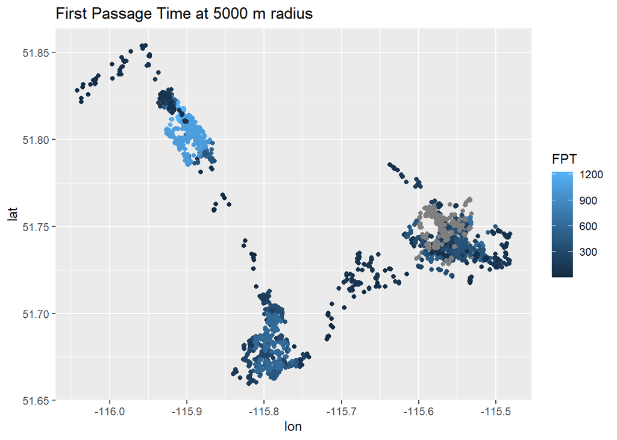

```r
ggplot(myelk, aes(lon, lat, col = FPT)) +  geom_point() +
  ggtitle("First Passage Time at 5000 m radius")
```

You can use a threshold here and try to pick out the periods when the animal is moving in a very directed way. Let’s just make this plot spatial as well.

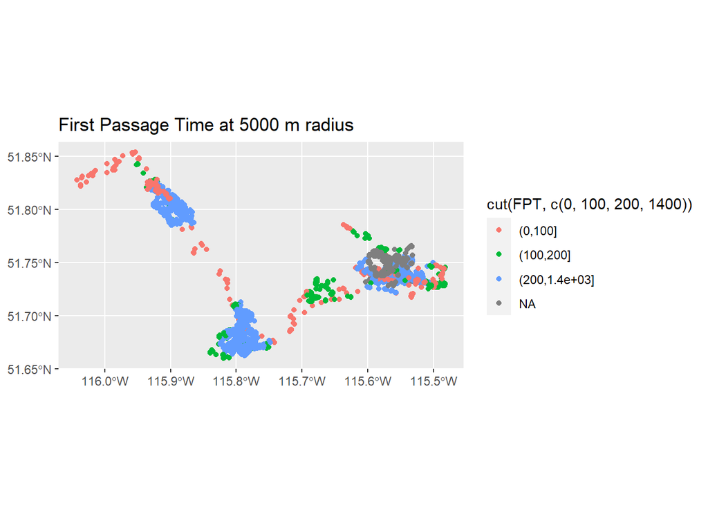

```r
myelk_sf <- myelk |>
  st_as_sf(coords=c("lon","lat"), crs= 4326) |>
  mutate(FPT = myelk_fpt[[1]]$r1)

ggplot(myelk_sf, aes(col = cut(FPT, c(0,100,200,1400)))) +
  geom_sf() +
  ggtitle("First Passage Time at 5000 m radius")
```

This is one way to break down the movement into very intensive, transitory, and intermediate “behaviors”.